# Assessing the Impact of NPIs on Consumer Mobility Patterns and COVID-19 Transmission in the US

Joseph Zuccarelli, Laura Seaman, Kevin Rader

2023-08-30

In the following markdown document, we carry out all mobility modeling using generalized linear mixed effects models.

## Mobility Modeling

First, we must read in our two datasets.

```r
# Read in data sets
MA_data <- read.csv("/Users/jqz0816/Documents/MDPI/Data/MA_data.csv")
MI_data <- read.csv("/Users/jqz0816/Documents/MDPI/Data/MI_data.csv")

# Format date/indicator features properly
MI_data$date <- as.Date(MI_data$date)
MA_data$date <- as.Date(MA_data$date)
MI_data$date_factor <- as.factor(MI_data$date)
MA_data$date_factor <- as.factor(MA_data$date)
MA_data$work_closing <- as.factor(MA_data$work_closing)
MA_data$gather_restrict <- as.factor(MA_data$gather_restrict)
MA_data$stay_home_reqs <- as.factor(MA_data$stay_home_reqs)
MI_data$work_closing <- as.factor(MI_data$work_closing)
MI_data$gather_restrict <- as.factor(MI_data$gather_restrict)
MI_data$stay_home_reqs <- as.factor(MI_data$stay_home_reqs)
```

Prior to performing any modeling, it is necessary to visualize the distributions of our variables.

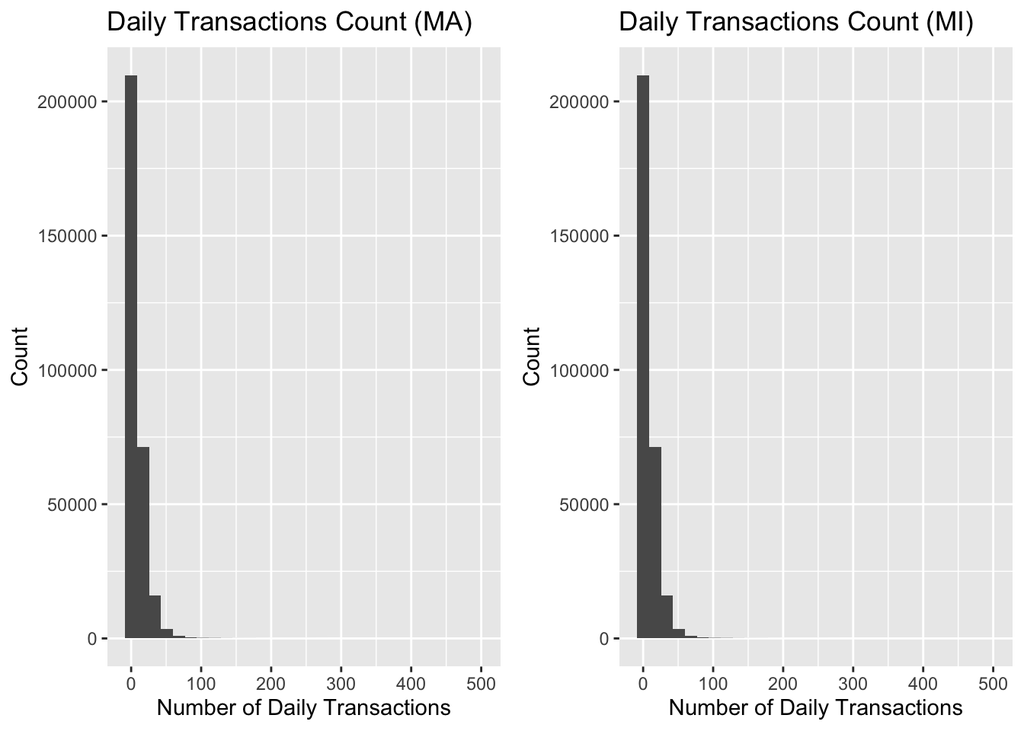

```r
# Histogram: Daily Transactions Count (MA Jan - May 2020)
MA_plot <- MA_data %>%
  ggplot(aes(x=num_transactions)) +
  geom_histogram()+
  labs(x="Number of Daily Transactions",y="Count",title="Daily Transactions Count (MA)")

# Histogram: Daily Transactions Count (MI Jan - May 2020)
MI_plot <- MA_data %>%
  ggplot(aes(x=num_transactions)) +
  geom_histogram()+
  labs(x="Number of Daily Transactions",y="Count",title="Daily Transactions Count (MI)")

# Subplots
plot_grid(MA_plot,MI_plot)
```

The plots above indicate that our data is heavily right-skewed; therefore, Poisson models are most appropriate. We will also check for over-dispersion, in which case negative binomial models would be necessary. Formally, our consumer mobility models are defined as follows:

$$\begin{equation}
\log(transactions_{ij}) = \beta_0 + \beta NPI_{i} + \beta weekend_{i}
+ \gamma_{0j}.
\end{equation}$$

The response variable, $transactions_{ij}$, denotes the POS transaction count observed on date $i$ for individual $j$. The indicator variable, $NPI_{i}$, represents one of the four interventions of interest in our study. Note that we treated each NPI as a categorical variable with multiple levels; therefore, fitting each separate model with four different NPI variables resulted in multiple $\beta$ coefficients due to one hot encoding. We controlled for seasonal patterns induced by the day of the week with the variable $weekend_{i}$. Similarly, we adjusted for individual-level effects with the term $\gamma_{0j}$, which represents the random intercept for individual $j$. We fit each model using a first-order autoregressive covariance structure with homogeneous variances to account for the time series nature of our data.

**Massachusetts**

**NPI: National Emergency**

```r
# Model: Daily Number of Transactions ~ National Emergency (MA)
modelMA <- glmmTMB(num_transactions ~ emergency + weekend +  (1|uuid) +
                  + ar1(date_factor + 0 |uuid),
                   family = poisson(),
                   data=MA_data)
```

```r
# Overdispersion test
check_overdispersion(modelMA)
```

```
## # Overdispersion test
##
##        dispersion ratio =     0.255
##   Pearson's Chi-Squared = 76868.620
##                 p-value =         1
```

```
## No overdispersion detected.
```

```r
# Model summary
summary(modelMA)
```

```
##  Family: poisson  ( log )
## Formula:
## num_transactions ~ emergency + weekend + (1 | uuid) + +ar1(date_factor +
##     0 | uuid)
## Data: MA_data
##
##       AIC       BIC    logLik  deviance  df.resid
## 1646911.1 1646974.8 -823449.5 1646899.1    301994
##
## Random effects:
##
## Conditional model:
##  Groups Name                  Variance Std.Dev. Corr
##  uuid   (Intercept)           0.8104   0.9002
##  uuid.1 date_factor2020-01-01 3.1067   1.7626   0.71 (ar1)
## Number of obs: 302000, groups:  uuid, 2000
##
## Conditional model:
##              Estimate Std. Error z value Pr(>|z|)
## (Intercept)  0.823915   0.023135   35.61  < 2e-16 ***
## emergency   -0.103869   0.014709   -7.06 1.65e-12 ***
## weekend     -0.214513   0.006004  -35.73  < 2e-16 ***
## ---
## Signif. codes:  0 '***' 0.001 '**' 0.01 '*' 0.05 '.' 0.1 ' ' 1
```

```r
# Fixed Effects
tidy(modelMA,exponentiate = TRUE,effects = 'fixed',conf.int = TRUE)
```

```
## # A tibble: 3 × 9
##   effect component term        estim…¹ std.e…² stati…³   p.value conf.…⁴ conf.…⁵
##   <chr>  <chr>     <chr>         <dbl>   <dbl>   <dbl>     <dbl>   <dbl>   <dbl>
## 1 fixed  cond      (Intercept)   2.28  0.0527    35.6  8.88e-278   2.18    2.39
## 2 fixed  cond      emergency     0.901 0.0133    -7.06 1.65e- 12   0.876   0.928
## 3 fixed  cond      weekend       0.807 0.00484  -35.7  1.36e-279   0.797   0.816
## # … with abbreviated variable names ¹estimate, ²std.error, ³statistic,
## #   ⁴conf.low, ⁵conf.high
```

```r
# ICC
rand_model <- icc_counts(MA_data,y='num_transactions',id='uuid',fam="poisson")
rand_model$ICC
```

```
##            ICC      SE ICC 95% CI LL 95% CI UL
## [1,] 0.8573699 0.006530773 0.8440275 0.8696517
```

**NPI: Workplace Closing**

```r
# Model: Daily Number of Transactions ~ Workplace Closing (MA)
modelMA <- glmmTMB(num_transactions ~ work_closing + weekend + (1 | uuid) +
                   ar1(date_factor + 0 |uuid),
                   family = poisson(),
                   data=MA_data)
```

```r
# Overdispersion test
check_overdispersion(modelMA)
```

```
## # Overdispersion test
##
##        dispersion ratio =     0.254
##   Pearson's Chi-Squared = 76844.242
##                 p-value =         1
```

```
## No overdispersion detected.
```

```r
# Model summary
summary(modelMA)
```

```
##  Family: poisson  ( log )
## Formula:
## num_transactions ~ work_closing + weekend + (1 | uuid) + ar1(date_factor +
##     0 | uuid)
## Data: MA_data
##
##       AIC       BIC    logLik  deviance  df.resid
## 1646810.2 1646873.9 -823399.1 1646798.2    301994
##
## Random effects:
##
## Conditional model:
##  Groups Name                  Variance Std.Dev. Corr
##  uuid   (Intercept)           0.8106   0.9003
##  uuid.1 date_factor2020-01-01 3.0946   1.7592   0.71 (ar1)
## Number of obs: 302000, groups:  uuid, 2000
##
## Conditional model:
##                Estimate Std. Error z value Pr(>|z|)
## (Intercept)    0.853156   0.022804   37.41   <2e-16 ***
## work_closing3 -0.182549   0.014810  -12.33   <2e-16 ***
## weekend       -0.215348   0.006004  -35.87   <2e-16 ***
## ---
## Signif. codes:  0 '***' 0.001 '**' 0.01 '*' 0.05 '.' 0.1 ' ' 1
```

```r
# Model output
tidy(modelMA,exponentiate = TRUE,effects = 'fixed',conf.int = TRUE)
```

```
## # A tibble: 3 × 9
##   effect component term        estim…¹ std.e…² stati…³   p.value conf.…⁴ conf.…⁵
##   <chr>  <chr>     <chr>         <dbl>   <dbl>   <dbl>     <dbl>   <dbl>   <dbl>
## 1 fixed  cond      (Intercept)   2.35  0.0535     37.4 2.45e-306   2.24    2.45
## 2 fixed  cond      work_closi…   0.833 0.0123    -12.3 6.58e- 35   0.809   0.858
## 3 fixed  cond      weekend       0.806 0.00484   -35.9 9.72e-282   0.797   0.816
## # … with abbreviated variable names ¹estimate, ²std.error, ³statistic,
## #   ⁴conf.low, ⁵conf.high
```

```r
# ICC
rand_model <- icc_counts(MA_data,y='num_transactions',id='uuid',fam="poisson")
rand_model$ICC
```

```
##            ICC      SE ICC 95% CI LL 95% CI UL
## [1,] 0.8573699 0.006530773 0.8440275 0.8696517
```

**NPI: Stay-at-Home Requirements**

```r
# Model: Daily Number of Transactions ~ Stay-at-Home Requirements (MA)
modelMA <- glmmTMB(num_transactions ~ stay_home_reqs + weekend + (1 |uuid) +
                   ar1(date_factor + 0 |uuid),
                   family = poisson(),
                   data=MA_data)
```

```r
# Overdispersion test
check_overdispersion(modelMA)
```

```
## # Overdispersion test
##
##        dispersion ratio =     0.254
##   Pearson's Chi-Squared = 76841.592
##                 p-value =         1
```

```
## No overdispersion detected.
```

```r
# Model summary
summary(modelMA)
```

```
##  Family: poisson  ( log )
## Formula:
## num_transactions ~ stay_home_reqs + weekend + (1 | uuid) + ar1(date_factor +
##     0 | uuid)
## Data: MA_data
##
##      AIC      BIC   logLik deviance df.resid
##  1646842  1646906  -823415  1646830   301994
##
## Random effects:
##
## Conditional model:
##  Groups Name                  Variance Std.Dev. Corr
##  uuid   (Intercept)           0.8106   0.9003
##  uuid.1 date_factor2020-01-01 3.0957   1.7595   0.71 (ar1)
## Number of obs: 302000, groups:  uuid, 2000
##
## Conditional model:
##                  Estimate Std. Error z value Pr(>|z|)
## (Intercept)      0.845958   0.022871   36.99   <2e-16 ***
## stay_home_reqs1 -0.162487   0.014841  -10.95   <2e-16 ***
## weekend         -0.218518   0.006012  -36.35   <2e-16 ***
## ---
## Signif. codes:  0 '***' 0.001 '**' 0.01 '*' 0.05 '.' 0.1 ' ' 1
```

```r
# Model output
tidy(modelMA,exponentiate = TRUE,effects = 'fixed',conf.int = TRUE)
```

```
## # A tibble: 3 × 9
##   effect component term        estim…¹ std.e…² stati…³   p.value conf.…⁴ conf.…⁵
##   <chr>  <chr>     <chr>         <dbl>   <dbl>   <dbl>     <dbl>   <dbl>   <dbl>
## 1 fixed  cond      (Intercept)   2.33  0.0533     37.0 1.74e-299   2.23    2.44
## 2 fixed  cond      stay_home_…   0.850 0.0126    -10.9 6.76e- 28   0.826   0.875
## 3 fixed  cond      weekend       0.804 0.00483   -36.3 2.96e-289   0.794   0.813
## # … with abbreviated variable names ¹estimate, ²std.error, ³statistic,
## #   ⁴conf.low, ⁵conf.high
```

```r
# ICC
rand_model <- icc_counts(MA_data,y='num_transactions',id='uuid',fam="poisson")
rand_model$ICC
```

```
##            ICC      SE ICC 95% CI LL 95% CI UL
## [1,] 0.8573699 0.006530773 0.8440275 0.8696517
```

**NPI: Gathering Restrictions**

```r
# Model: Daily Number of Transactions ~ Gathering Restrictions (MA)
modelMA <- glmmTMB(num_transactions ~ gather_restrict + weekend + (1|uuid) +
                   ar1(date_factor + 0 |uuid),
                   family = poisson(),
                   data=MA_data)
```

```r
# Overdispersion test
check_overdispersion(modelMA)
```

```
## # Overdispersion test
##
##        dispersion ratio =     0.254
##   Pearson's Chi-Squared = 76849.108
##                 p-value =         1
```

```
## No overdispersion detected.
```

```r
# Model summary
summary(modelMA)
```

```
##  Family: poisson  ( log )
## Formula:
## num_transactions ~ gather_restrict + weekend + (1 | uuid) + ar1(date_factor +
##     0 | uuid)
## Data: MA_data
##
##      AIC      BIC   logLik deviance df.resid
##  1646856  1646941  -823420  1646840   301992
##
## Random effects:
##
## Conditional model:
##  Groups Name                  Variance Std.Dev. Corr
##  uuid   (Intercept)           0.8104   0.9002
##  uuid.1 date_factor2020-01-01 3.0970   1.7598   0.71 (ar1)
## Number of obs: 302000, groups:  uuid, 2000
##
## Conditional model:
##                   Estimate Std. Error z value Pr(>|z|)
## (Intercept)       0.839094   0.023191   36.18  < 2e-16 ***
## gather_restrict2  0.052329   0.025511    2.05   0.0402 *
## gather_restrict3 -0.098775   0.019529   -5.06 4.24e-07 ***
## gather_restrict4 -0.157952   0.016646   -9.49  < 2e-16 ***
## weekend          -0.214606   0.006015  -35.68  < 2e-16 ***
## ---
## Signif. codes:  0 '***' 0.001 '**' 0.01 '*' 0.05 '.' 0.1 ' ' 1
```

```r
# Model output
tidy(modelMA,exponentiate = TRUE,effects = 'fixed',conf.int = TRUE)
```

```
## # A tibble: 5 × 9
##   effect component term        estim…¹ std.e…² stati…³   p.value conf.…⁴ conf.…⁵
##   <chr>  <chr>     <chr>         <dbl>   <dbl>   <dbl>     <dbl>   <dbl>   <dbl>
## 1 fixed  cond      (Intercept)   2.31  0.0537    36.2  1.20e-286   2.21    2.42
## 2 fixed  cond      gather_res…   1.05  0.0269     2.05 4.02e-  2   1.00    1.11
## 3 fixed  cond      gather_res…   0.906 0.0177    -5.06 4.24e-  7   0.872   0.941
## 4 fixed  cond      gather_res…   0.854 0.0142    -9.49 2.34e- 21   0.826   0.882
## 5 fixed  cond      weekend       0.807 0.00485  -35.7  7.77e-279   0.797   0.816
## # … with abbreviated variable names ¹estimate, ²std.error, ³statistic,
## #   ⁴conf.low, ⁵conf.high
```

```r
# ICC
rand_model <- icc_counts(MA_data,y='num_transactions',id='uuid',fam="poisson")
rand_model$ICC
```

```
##            ICC      SE ICC 95% CI LL 95% CI UL
## [1,] 0.8573699 0.006530773 0.8440275 0.8696517
```

**Michigan**

**NPI: National Emergency**

```r
# Model: Daily Number of Transactions ~ National Emergency (MI)
modelMI <- glmmTMB(num_transactions ~ emergency + weekend + (1|uuid) +
                  + ar1(date_factor + 0 |uuid),
                   family = poisson(),
                   data=MI_data)
```

```r
# Overdispersion test
check_overdispersion(modelMI)
```

```
## # Overdispersion test
##
##        dispersion ratio =     0.255
##   Pearson's Chi-Squared = 77105.761
##                 p-value =         1
```

```
## No overdispersion detected.
```

```r
# Model summary
summary(modelMI)
```

```
##  Family: poisson  ( log )
## Formula:
## num_transactions ~ emergency + weekend + (1 | uuid) + +ar1(date_factor +
##     0 | uuid)
## Data: MI_data
##
##       AIC       BIC    logLik  deviance  df.resid
## 1726337.4 1726401.1 -863162.7 1726325.4    301994
##
## Random effects:
##
## Conditional model:
##  Groups Name                  Variance Std.Dev. Corr
##  uuid   (Intercept)           0.5603   0.7486
##  uuid.1 date_factor2020-01-01 2.5046   1.5826   0.61 (ar1)
## Number of obs: 302000, groups:  uuid, 2000
##
## Conditional model:
##              Estimate Std. Error z value Pr(>|z|)
## (Intercept)  1.157167   0.018917   61.17   <2e-16 ***
## emergency   -0.267972   0.011612  -23.08   <2e-16 ***
## weekend     -0.255138   0.006031  -42.30   <2e-16 ***
## ---
## Signif. codes:  0 '***' 0.001 '**' 0.01 '*' 0.05 '.' 0.1 ' ' 1
```

```r
# Model output
tidy(modelMI,exponentiate = TRUE,effects = 'fixed',conf.int = TRUE)
```

```
## # A tibble: 3 × 9
##   effect component term        estim…¹ std.e…² stati…³   p.value conf.…⁴ conf.…⁵
##   <chr>  <chr>     <chr>         <dbl>   <dbl>   <dbl>     <dbl>   <dbl>   <dbl>
## 1 fixed  cond      (Intercept)   3.18  0.0602     61.2 0           3.07    3.30
## 2 fixed  cond      emergency     0.765 0.00888   -23.1 8.00e-118   0.748   0.783
## 3 fixed  cond      weekend       0.775 0.00467   -42.3 0           0.766   0.784
## # … with abbreviated variable names ¹estimate, ²std.error, ³statistic,
## #   ⁴conf.low, ⁵conf.high
```

```r
# ICC
rand_model <- icc_counts(MI_data,y='num_transactions',id='uuid',fam="poisson")
rand_model$ICC
```

```
##            ICC      SE ICC 95% CI LL 95% CI UL
## [1,] 0.7942555 0.007704256 0.7786574 0.8088725
```

**NPI: Workplace Closing**

```r
# Model: Daily Number of Transactions ~ Workplace Closing (MI)
modelMI <- glmmTMB(num_transactions ~ work_closing + weekend + (1 |uuid) +
                   ar1(date_factor + 0 |uuid),
                   family = poisson(),
                   data=MI_data)
```

```r
# Overdispersion test
check_overdispersion(modelMI)
```

```
## # Overdispersion test
##
##        dispersion ratio =     0.255
##   Pearson's Chi-Squared = 77078.889
##                 p-value =         1
```

```
## No overdispersion detected.
```

```r
# Model summary
summary(modelMI)
```

```
##  Family: poisson  ( log )
## Formula:
## num_transactions ~ work_closing + weekend + (1 | uuid) + ar1(date_factor +
##     0 | uuid)
## Data: MI_data
##
##      AIC      BIC   logLik deviance df.resid
##  1725580  1725654  -862783  1725566   301993
##
## Random effects:
##
## Conditional model:
##  Groups Name                  Variance Std.Dev. Corr
##  uuid   (Intercept)           0.5609   0.7489
##  uuid.1 date_factor2020-01-01 2.4688   1.5712   0.60 (ar1)
## Number of obs: 302000, groups:  uuid, 2000
##
## Conditional model:
##                Estimate Std. Error z value Pr(>|z|)
## (Intercept)    1.175148   0.018825   62.43   <2e-16 ***
## work_closing2 -0.150070   0.012708  -11.81   <2e-16 ***
## work_closing3 -0.537347   0.014863  -36.15   <2e-16 ***
## weekend       -0.263978   0.006035  -43.74   <2e-16 ***
## ---
## Signif. codes:  0 '***' 0.001 '**' 0.01 '*' 0.05 '.' 0.1 ' ' 1
```

```r
# Model output
tidy(modelMI,exponentiate = TRUE,effects = 'fixed',conf.int = TRUE)
```

```
## # A tibble: 4 × 9
##   effect component term        estim…¹ std.e…² stati…³   p.value conf.…⁴ conf.…⁵
##   <chr>  <chr>     <chr>         <dbl>   <dbl>   <dbl>     <dbl>   <dbl>   <dbl>
## 1 fixed  cond      (Intercept)   3.24  0.0610     62.4 0           3.12    3.36
## 2 fixed  cond      work_closi…   0.861 0.0109    -11.8 3.49e- 32   0.839   0.882
## 3 fixed  cond      work_closi…   0.584 0.00868   -36.2 3.21e-286   0.568   0.602
## 4 fixed  cond      weekend       0.768 0.00463   -43.7 0           0.759   0.777
## # … with abbreviated variable names ¹estimate, ²std.error, ³statistic,
## #   ⁴conf.low, ⁵conf.high
```

```r
# ICC
rand_model <- icc_counts(MI_data,y='num_transactions',id='uuid',fam="poisson")
rand_model$ICC
```

```
##            ICC      SE ICC 95% CI LL 95% CI UL
## [1,] 0.7942555 0.007704256 0.7786574 0.8088725
```

**NPI: Stay-at-Home Requirements**

```r
# Model: Daily Number of Transactions ~ Stay-at-Home Requirements (MI)
modelMI <- glmmTMB(num_transactions ~ stay_home_reqs + weekend + (1 |uuid) +
                   ar1(date_factor + 0 |uuid),
                   family = poisson(),
                   data=MI_data)
```

```r
# Overdispersion test
check_overdispersion(modelMI)
```

```
## # Overdispersion test
##
##        dispersion ratio =     0.255
##   Pearson's Chi-Squared = 77130.777
##                 p-value =         1
```

```
## No overdispersion detected.
```

```r
# Model summary
summary(modelMI)
```

```
##  Family: poisson  ( log )
## Formula:
## num_transactions ~ stay_home_reqs + weekend + (1 | uuid) + ar1(date_factor +
##     0 | uuid)
## Data: MI_data
##
##       AIC       BIC    logLik  deviance  df.resid
## 1725998.8 1726073.1 -862992.4 1725984.8    301993
##
## Random effects:
##
## Conditional model:
##  Groups Name                  Variance Std.Dev. Corr
##  uuid   (Intercept)           0.5603   0.7485
##  uuid.1 date_factor2020-01-01 2.4931   1.5790   0.61 (ar1)
## Number of obs: 302000, groups:  uuid, 2000
##
## Conditional model:
##                  Estimate Std. Error z value Pr(>|z|)
## (Intercept)      1.167924   0.018954   61.62  < 2e-16 ***
## stay_home_reqs1 -0.075196   0.015108   -4.98 6.45e-07 ***
## stay_home_reqs2 -0.363830   0.012728  -28.59  < 2e-16 ***
## weekend         -0.258797   0.006029  -42.92  < 2e-16 ***
## ---
## Signif. codes:  0 '***' 0.001 '**' 0.01 '*' 0.05 '.' 0.1 ' ' 1
```

```r
# Model output
tidy(modelMI,exponentiate = TRUE,effects = 'fixed',conf.int = TRUE)
```

```
## # A tibble: 4 × 9
##   effect component term        estim…¹ std.e…² stati…³   p.value conf.…⁴ conf.…⁵
##   <chr>  <chr>     <chr>         <dbl>   <dbl>   <dbl>     <dbl>   <dbl>   <dbl>
## 1 fixed  cond      (Intercept)   3.22  0.0609    61.6  0           3.10    3.34
## 2 fixed  cond      stay_home_…   0.928 0.0140    -4.98 6.45e-  7   0.900   0.955
## 3 fixed  cond      stay_home_…   0.695 0.00885  -28.6  1.01e-179   0.678   0.713
## 4 fixed  cond      weekend       0.772 0.00465  -42.9  0           0.763   0.781
## # … with abbreviated variable names ¹estimate, ²std.error, ³statistic,
## #   ⁴conf.low, ⁵conf.high
```

```r
# ICC
rand_model <- icc_counts(MI_data,y='num_transactions',id='uuid',fam="poisson")
rand_model$ICC
```

```
##            ICC      SE ICC 95% CI LL 95% CI UL
## [1,] 0.7942555 0.007704256 0.7786574 0.8088725
```

**NPI: Gathering Restrictions**

```r
# Model: Daily Number of Transactions ~ Gathering Restrictions (MI)
modelMI <- glmmTMB(num_transactions ~ gather_restrict + weekend + (1|uuid) +
                   ar1(date_factor + 0 |uuid),
                   family = poisson(),
                   data=MI_data)
```

```r
# Overdispersion test
check_overdispersion(modelMI)
```

```
## # Overdispersion test
##
##        dispersion ratio =     0.255
##   Pearson's Chi-Squared = 77123.585
##                 p-value =         1
```

```
## No overdispersion detected.
```

```r
# Model summary
summary(modelMI)
```

```
##  Family: poisson  ( log )
## Formula:
## num_transactions ~ gather_restrict + weekend + (1 | uuid) + ar1(date_factor +
##     0 | uuid)
## Data: MI_data
##
##       AIC       BIC    logLik  deviance  df.resid
## 1725955.9 1726040.8 -862969.9 1725939.9    301992
##
## Random effects:
##
## Conditional model:
##  Groups Name                  Variance Std.Dev. Corr
##  uuid   (Intercept)           0.5606   0.7487
##  uuid.1 date_factor2020-01-01 2.4960   1.5799   0.61 (ar1)
## Number of obs: 302000, groups:  uuid, 2000
##
## Conditional model:
##                   Estimate Std. Error z value Pr(>|z|)
## (Intercept)       1.176489   0.018924   62.17  < 2e-16 ***
## gather_restrict2  0.127111   0.024619    5.16 2.43e-07 ***
## gather_restrict3 -0.081145   0.022912   -3.54 0.000398 ***
## gather_restrict4 -0.349751   0.012294  -28.45  < 2e-16 ***
## weekend          -0.258415   0.006031  -42.85  < 2e-16 ***
## ---
## Signif. codes:  0 '***' 0.001 '**' 0.01 '*' 0.05 '.' 0.1 ' ' 1
```

```r
# Model output
tidy(modelMI,exponentiate = TRUE,effects = 'fixed',conf.int = TRUE)
```

```
## # A tibble: 5 × 9
##   effect component term        estim…¹ std.e…² stati…³   p.value conf.…⁴ conf.…⁵
##   <chr>  <chr>     <chr>         <dbl>   <dbl>   <dbl>     <dbl>   <dbl>   <dbl>
## 1 fixed  cond      (Intercept)   3.24  0.0614    62.2  0           3.12    3.37
## 2 fixed  cond      gather_res…   1.14  0.0280     5.16 2.43e-  7   1.08    1.19
## 3 fixed  cond      gather_res…   0.922 0.0211    -3.54 3.98e-  4   0.882   0.964
## 4 fixed  cond      gather_res…   0.705 0.00867  -28.4  5.06e-178   0.688   0.722
## 5 fixed  cond      weekend       0.772 0.00466  -42.8  0           0.763   0.781
## # … with abbreviated variable names ¹estimate, ²std.error, ³statistic,
## #   ⁴conf.low, ⁵conf.high
```

```r
# ICC
rand_model <- icc_counts(MI_data,y='num_transactions',id='uuid',fam="poisson")
rand_model$ICC
```

```
##            ICC      SE ICC 95% CI LL 95% CI UL
## [1,] 0.7942555 0.007704256 0.7786574 0.8088725
```